# Balade en statistique spatiale

Initiation tranquille à l’hétérogénéité spatiale

Grégoire Le Campion - UMR Passages CNRS

DECA 4 - 1er semestre 2026 05/01/2025

## Introduction

## Objectifs du cours

- Comprendre les limites de la régression classique
- Découvrir les enjeux de la dimension spatiale en analyse de données
- Découvrir les concepts fondamentaux de la statistique spatiale
- Appliquer ces méthodes avec R
- Découvrir d’autres outils de représentation : Geoda et Magrit

## Plan

1. Rappels : Régression linéaire classique
2. Introduction à la statistique spatiale
3. L’autocorrélation spatiale
4. Indicateurs locaux (LISA)
5. L’hétérogénéité spatiale et la GWR
6. (les autres méthodes de l’hétérogénéité spatiale)
7. (Les modèles de régressions spatiale)

## Environnement de travail

## [R : le moteur !](https://cran.r-project.org/bin/windows/base/)

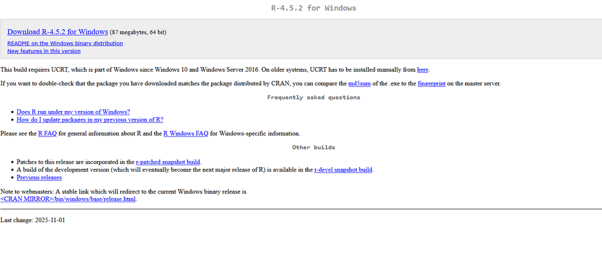

## [Rstudio : l’interface de travail](https://posit.co/download/rstudio-desktop/)

[figure not shown]

## [Geoda : fait pour l’autocorrelation et les LISA](https://geodacenter.github.io/download/)

[figure not shown]

## [Magrit : le logiciel de carto !](https://magrit.cnrs.fr/)

[figure not shown]

## [Github : accéder à tout le cours](https://github.com/LeCampionG/deca4_2026)

[figure not shown]

## Premier pas en codage !

**Etape 1**

Double-cliquer sur le fichier `script_liste_packages.r`

```r
# Pour installer un package

install.packages("mapsf")

# Pour l'appeler dans r

library(mapsf)
```

**Félicitaions**

Bravo vous voilà développeurs !

## Découverte des données

## Charger les données tabulaires

On utilise le package `here` pour gérer les chemins d’accès, ici on spécifie où on se situe :

```r
library(here)

csv_path <- here("data", "donnees_standr.csv")
immo_df <- read.csv2(csv_path)

#Pour visualiser les données
library(DT)

# datatable(head(immo_df, 10))
```

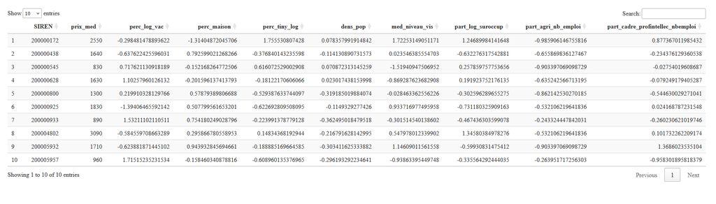

## Charger des données spatiales

```r
library(sf)


shp_path <- here("data", "EPCI.shp")
epci_sf <- st_read(shp_path)
# et la table attributaire correspondante, avec le package DT
 # datatable(head(epci_sf, 10))
```

[figure not shown]

## Pour représenter vos données spatiale

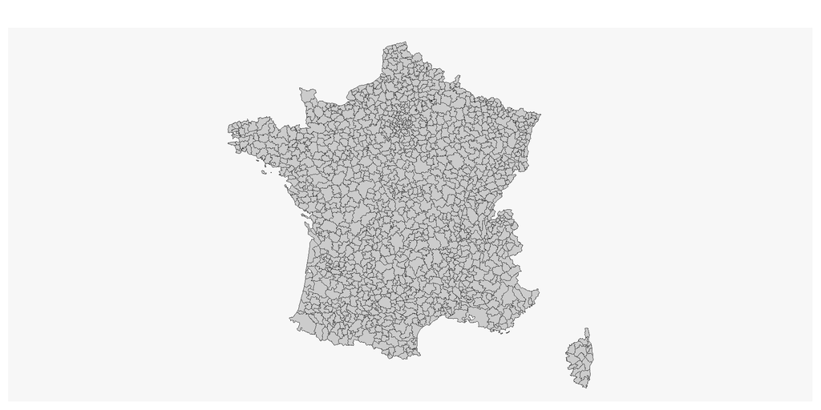

```r
library(mapsf)

# pour voir les données géographiques
mf_map(x = epci_sf)
```

## Rappels : La Régression Linéaire

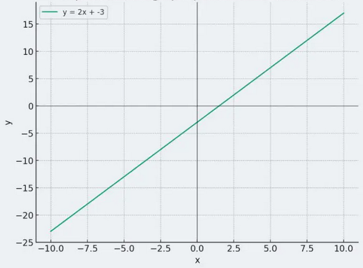

## Qu’est-ce que la régression linéaire ?

**La régression linéaire cherche à expliquer ou prédire une variable Y par une ou plusieurs variables X.**

Elle peut être simple :

$$Y = a + bX + \epsilon$$

Ou multiple :

$$Y = \beta_0 + \beta_1 X_1 + \beta_2 X_2 + ... + \beta_n X_n + \epsilon$$

- $\beta_0$ : ordonnée à l’origine
- $\beta_i$ : coefficients de régression
- $\epsilon$ : terme d’erreur

## Ce que permet la régression linéaire

**Objectifs**

- Quantifier les relations entre variables
- Prédire des valeurs
- Tester des hypothèses
- Identifier les variables significatives

**Exemple simple**

Prix d’un bien immobilier :

- Surface
- Nombre de pièces
- Localisation (code postal)

## Visualisation du modèle

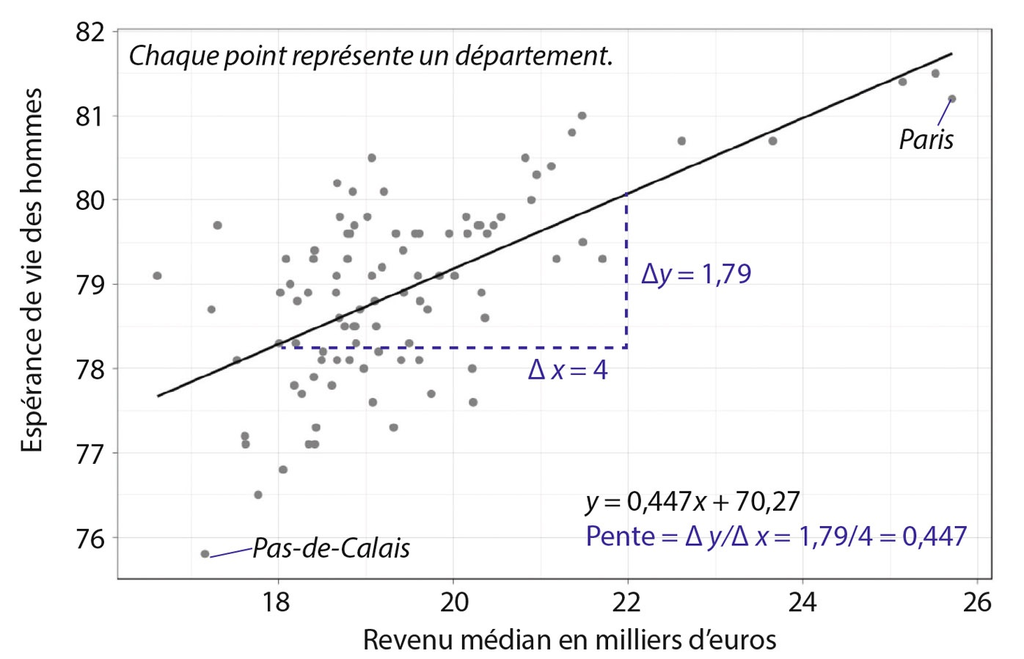

*Figure issue de Feuillet, T., Cossart, É. et Commenges, H. (2019). Chapitre 7. La régression linéaire. Manuel de géographie quantitative : Concepts, outils, méthodes (p. 158-179). Armand Colin.*

## Visualisation du modèle 2

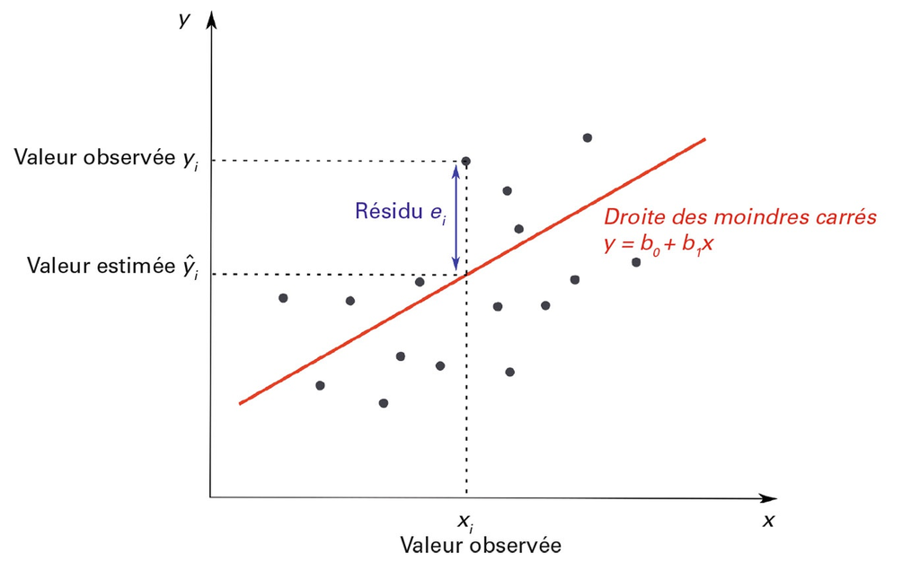

*Figure issue de Feuillet, T., Cossart, É. et Commenges, H. (2019). Chapitre 7. La régression linéaire. Manuel de géographie quantitative : Concepts, outils, méthodes (p. 158-179). Armand Colin.*

## Interpréter les coefficients

**Exemple** : Y = 2 000 + 500 × X

**Prédiction** : Une personne avec 5 ans d’expérience :

Y = 2 000 + 500 × 5 = **4 500 €**

## Visualisation du modèle de l’exemple

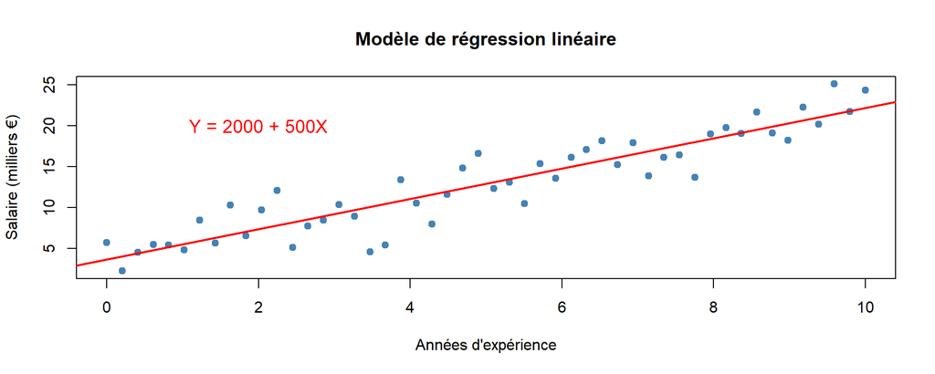

## Qualité du modèle : R²

**Coefficient de détermination**

$$R^2 = 1 - \frac{\text{Variance résiduelle}}{\text{Variance totale}}$$

**Interprétation** :

- Varie de 0 à 1
- R² = 0,75 → le modèle explique **75%** de la variabilité de Y

## Interpréter R²

| R² | Interprétation |
| --- | --- |
| < 0,3 | Modèle faible |
| 0,3 - 0,6 | Modèle moyen |
| 0,6 - 0,8 | Bon modèle |
| > 0,8 | Excellent modèle |

**Note**

En SHS, un R² de 0,3-0,5 n’est pas rare.

## Mise en pratique avec R

## Représentater le modèle avec R

Essayons tout d’abord de représenter un modèle !

Nous cherchons à expliquer le prix median de l’immobilier par le niveau de vie médian des menages par EPCI :

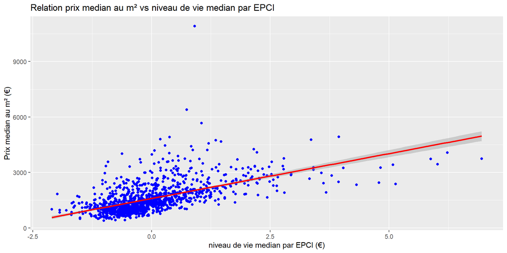

```r
library(ggplot2)

plot1 <- ggplot(immo_df, aes(x = med_niveau_vis, y = prix_med)) +
                         geom_point() +
                         labs(title = "Relation prix median au m² vs niveau de vie median par EPCI") +
                         xlab("niveau de vie median par EPCI (€)") + ylab("Prix median au m² (€)")+
                         theme(plot.title = element_text(face = "bold"))

plot1 + geom_point(col="blue") + geom_smooth(method = "lm", color="red", se=TRUE) + theme_grey()
```

## Représentater le modèle avec R 2

Une autre manière de faire qui peut s’avérer pratique…

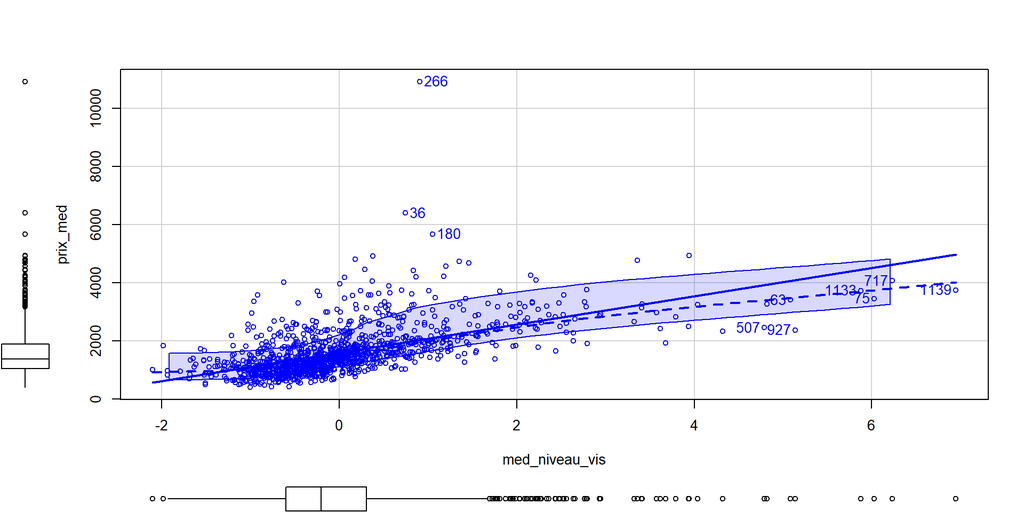

```
 [1]   36   63   75  180  266  507  717  927 1133 1139
```

```r
library(car)

car::scatterplot(prix_med ~ med_niveau_vis, data = immo_df, id = list(n=10))
```

## Créer le modèle statistique

Produire un modèle de régression rien de plus simple !

```r
# Estimation du modèle avec la fonction lm (pour linear model)
lm1 <- lm(data = immo_df, formula = prix_med ~ med_niveau_vis)

summary(lm1)
```

```
Call:
lm(formula = prix_med ~ med_niveau_vis, data = immo_df)

Residuals:
    Min      1Q  Median      3Q     Max
-1717.4  -374.0  -147.5   172.0  8888.1

Coefficients:
               Estimate Std. Error t value Pr(>|t|)
(Intercept)     1590.85      19.22   82.77   <2e-16 ***
med_niveau_vis   485.91      19.21   25.30   <2e-16 ***
---
Signif. codes:  0 '***' 0.001 '**' 0.01 '*' 0.05 '.' 0.1 ' ' 1

Residual standard error: 672.2 on 1221 degrees of freedom
Multiple R-squared:  0.3439,    Adjusted R-squared:  0.3434
F-statistic:   640 on 1 and 1221 DF,  p-value: < 2.2e-16
```

## Premiers résultats

La fonction summary() présente les estimations de façon brute, mais d’autres fonctions permettent des rendus plus esthétiques, comme avec le package gtsummary :

```r
library(gtsummary)

# En tableau
gtsummary::tbl_regression(lm1)
```

| **Characteristic** | **Beta** | **95% CI** | **p-value** |
| --- | --- | --- | --- |
| med_niveau_vis | 486 | 448, 524 | <0.001 |

Abbreviation: CI = Confidence Interval

## Condition de réalisation d’une régression

## Les hypothèses de la régression classique

1. **Linéarité** : relation linéaire entre Y et X
2. **Indépendance** : les observations sont indépendantes
3. **Homoscédasticité** : variance constante des résidus
4. **Normalité** : distribution normale des résidus
5. **Pas d’autocorrélation** : les résidus ne doivent pas être auto-corrélés
6. **Non-colinéarité** : les variables explicatives ne sont pas trop corrélées

## Limites de la régression classique (1/2)

### Hypothèse d’indépendance des observations

En géographie, cette hypothèse est souvent **violée** :

- Les phénomènes spatiaux sont rarement indépendants : **on parle de la dépendance spatiale : autocorrélation des résidus.**
- “Tout est lié à tout, mais les choses proches sont plus liées que les choses éloignées” (Tobler, 1970)

## Limites de la régression classique (2/2)

### Hypothèse de stationnarité

La régression classique suppose des **coefficients constants** dans l’espace :

- L’effet d’une variable est le même partout
- Pas de prise en compte des variations locales
- Inadapté pour des phénomènes géographiques hétérogènes et plus largement en SHS

## Diagnostiquer la régression avec R

## On complexifie notre modèle

**Attention**

Avant de lancer ce modèle des conditions d’applications doivent être vérifiées!

```r
mod.lm <- lm(formula = prix_med ~ perc_log_vac + perc_maison +
                      perc_tiny_log + dens_pop + med_niveau_vis +
                      part_log_suroccup + part_agri_nb_emploi +
                      part_cadre_profintellec_nbemploi, data = immo_df)


gtsummary::tbl_regression(mod.lm)
```

| **Characteristic** | **Beta** | **95% CI** | **p-value** |
| --- | --- | --- | --- |
| perc_log_vac | -287 | -315, -260 | <0.001 |
| perc_maison | -128 | -168, -89 | <0.001 |
| perc_tiny_log | -262 | -316, -207 | <0.001 |
| dens_pop | 174 | 144, 204 | <0.001 |
| med_niveau_vis | 288 | 261, 315 | <0.001 |
| part_log_suroccup | 389 | 335, 443 | <0.001 |
| part_agri_nb_emploi | -21 | -50, 8.8 | 0.2 |
| part_cadre_profintellec_nbemploi | -7.8 | -47, 31 | 0.7 |

Abbreviation: CI = Confidence Interval

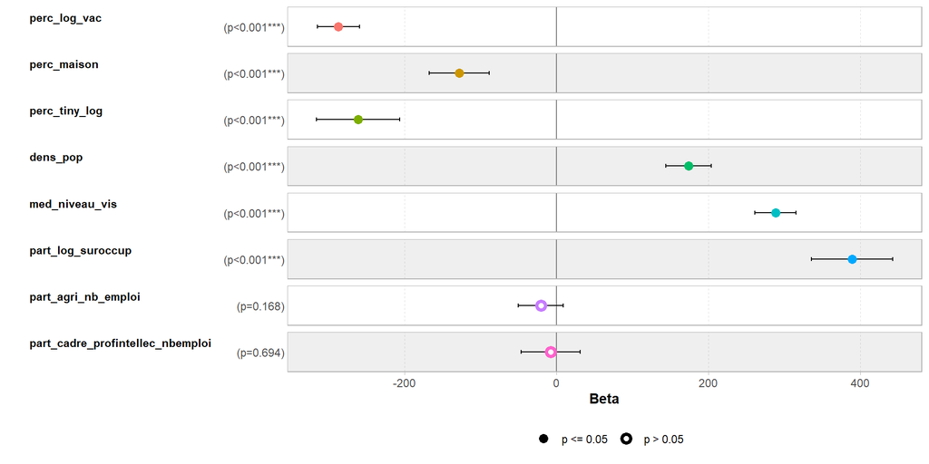

```r
GGally::ggcoef_model(mod.lm)
```

## Exploration des variables en jeu

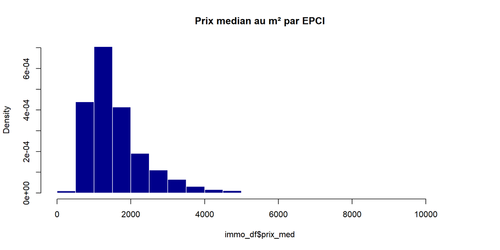

```r
# Distribution de la variable dépendante :
hist(immo_df$prix_med, freq=FALSE, breaks = 35, col = "darkblue", border = "white",
     main = "Prix median au m² par EPCI")
```

## La linéarité de la relation entre VD et VI

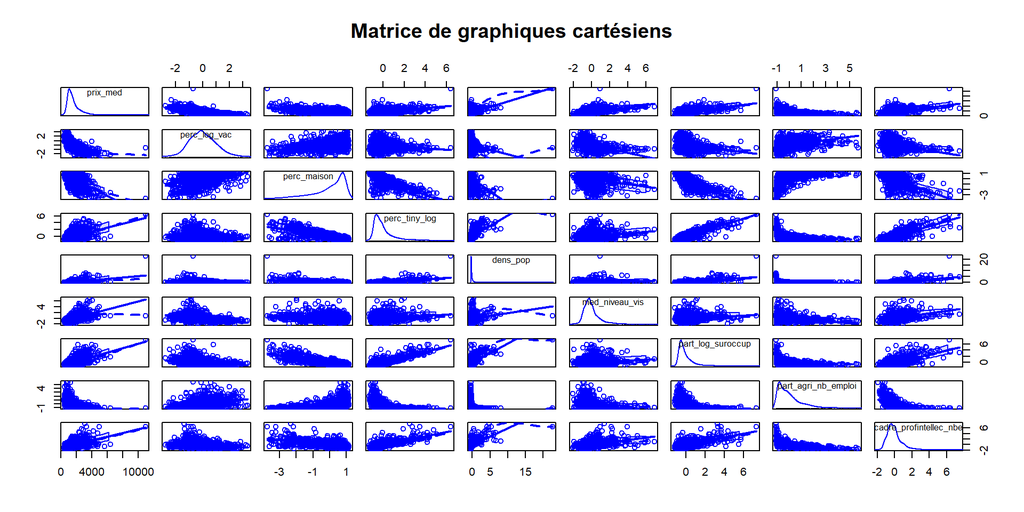

```r
library(car)

scatterplotMatrix(~prix_med + perc_log_vac + perc_maison +
                    perc_tiny_log + dens_pop + med_niveau_vis +
                    part_log_suroccup + part_agri_nb_emploi +
                    part_cadre_profintellec_nbemploi,
                   data=immo_df, smoother=loessLine,
                  main="Matrice de graphiques cartésiens")
```

## La multicolinéarité entre les VI

### Etude des corrélations

```r
library(correlation)

data_cor <- immo_df %>% select(-SIREN)
immo_cor <- correlation(data_cor, redundant = TRUE)
summary(immo_cor)
```

```
# Correlation Matrix (pearson-method)

Parameter                        | part_cadre_profintellec_nbemploi
-------------------------------------------------------------------
prix_med                         |                          0.55***
perc_log_vac                     |                         -0.31***
perc_maison                      |                         -0.58***
perc_tiny_log                    |                          0.75***
dens_pop                         |                          0.59***
med_niveau_vis                   |                          0.43***
part_log_suroccup                |                          0.65***
part_agri_nb_emploi              |                         -0.57***
part_cadre_profintellec_nbemploi |                          1.00***

Parameter                        | part_agri_nb_emploi | part_log_suroccup
--------------------------------------------------------------------------
prix_med                         |            -0.45*** |           0.60***
perc_log_vac                     |             0.39*** |          -0.28***
perc_maison                      |             0.54*** |          -0.79***
perc_tiny_log                    |            -0.51*** |           0.87***
dens_pop                         |            -0.29*** |           0.62***
med_niveau_vis                   |            -0.33*** |           0.15***
part_log_suroccup                |            -0.43*** |           1.00***
part_agri_nb_emploi              |             1.00*** |
part_cadre_profintellec_nbemploi |                     |

Parameter                        | med_niveau_vis | dens_pop | perc_tiny_log
----------------------------------------------------------------------------
prix_med                         |        0.59*** |  0.52*** |       0.49***
perc_log_vac                     |       -0.46*** | -0.21*** |      -0.19***
perc_maison                      |       -0.24*** | -0.46*** |      -0.75***
perc_tiny_log                    |        0.22*** |  0.62*** |       1.00***
dens_pop                         |        0.18*** |  1.00*** |
med_niveau_vis                   |        1.00*** |          |
part_log_suroccup                |                |          |
part_agri_nb_emploi              |                |          |
part_cadre_profintellec_nbemploi |                |          |

Parameter                        | perc_maison | perc_log_vac | prix_med
------------------------------------------------------------------------
prix_med                         |    -0.60*** |     -0.68*** |  1.00***
perc_log_vac                     |     0.35*** |      1.00*** |
perc_maison                      |     1.00*** |              |
perc_tiny_log                    |             |              |
dens_pop                         |             |              |
med_niveau_vis                   |             |              |
part_log_suroccup                |             |              |
part_agri_nb_emploi              |             |              |
part_cadre_profintellec_nbemploi |             |              |

p-value adjustment method: Holm (1979)
```

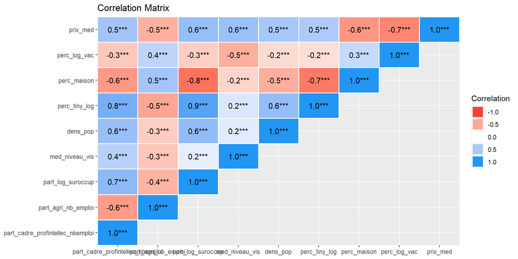

```r
library(see)
immo_cor %>%
  summary(redundant = FALSE) %>%
  plot(type="tile", show_labels =TRUE, show_p = TRUE, digits = 1, size_text=3)
```

## La multicolinéarité entre les VI

### Le VIF

**VIF**

La VIF (Variance Inflation Factor) est une très bonne méthode pour vérifier les risques de multicolinéarité. Elle suppose simplement d’avoir estimé un premier modèle pour être utilisée.

```r
library(car)

vif(mod.lm)
```

```
                    perc_log_vac                      perc_maison
                        1.577984                         3.204058
                   perc_tiny_log                         dens_pop
                        6.221631                         1.864236
                  med_niveau_vis                part_log_suroccup
                        1.532403                         5.977951
             part_agri_nb_emploi part_cadre_profintellec_nbemploi
                        1.812419                         3.162576
```

```r
# On peut aussi directement l'ajouter au résumé des coefficient obtenu avec gtsummary

library(gtsummary)

mod.lm %>%
  tbl_regression(intercept = TRUE) %>% add_vif()
```

| **Characteristic** | **Beta** | **95% CI** | **p-value** | **VIF** |
| --- | --- | --- | --- | --- |
| (Intercept) | 1,593 | 1,571, 1,615 | <0.001 |  |
| perc_log_vac | -287 | -315, -260 | <0.001 | 1.6 |
| perc_maison | -128 | -168, -89 | <0.001 | 3.2 |
| perc_tiny_log | -262 | -316, -207 | <0.001 | 6.2 |
| dens_pop | 174 | 144, 204 | <0.001 | 1.9 |
| med_niveau_vis | 288 | 261, 315 | <0.001 | 1.5 |
| part_log_suroccup | 389 | 335, 443 | <0.001 | 6.0 |
| part_agri_nb_emploi | -21 | -50, 8.8 | 0.2 | 1.8 |
| part_cadre_profintellec_nbemploi | -7.8 | -47, 31 | 0.7 | 3.2 |

Abbreviations: CI = Confidence Interval, VIF = Variance Inflation Factor

## Analyse des résidus

**Notes**

L’analyse des résidus est très importante car les conditions de validité d’un modèle linéaire au delà des résultats repose grandement sur les résidus. Ils permettent en outre d’identifier les individus extrêmes (ou outliers).

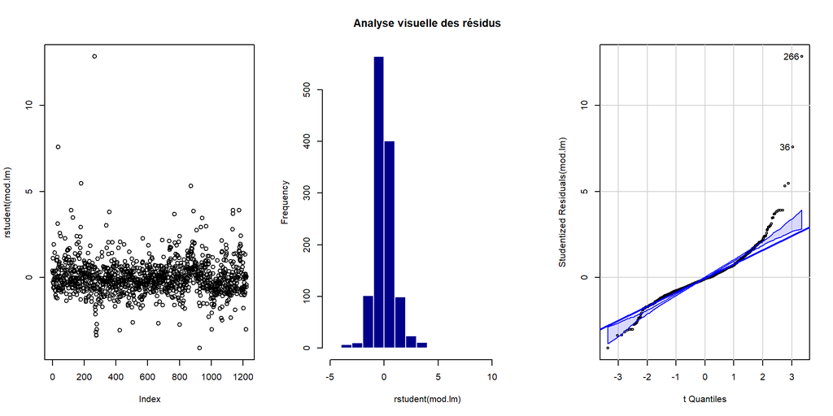

```
[1]  36 266
```

```r
par(mfrow=c(1,3))
plot(rstudent(mod.lm))
hist(rstudent(mod.lm), breaks = 20, col="darkblue", border="white", main="Analyse visuelle des résidus")
qqPlot(mod.lm)
```

## Analyse des résidus 2

Si la voie graphique ne vous inspire pas il existe des tests statistiques qui permettent de vérifier la normalité des résidus ou bien leur homoscédasticité.

Ils ont cela de particulier qu’ici nous cherchons à accepter H0 et donc pour valider la normalité ou l’homoscédasticité il faut que $p−value>0.05$

```r
# Pour étudier la normalité on peut utiliser le test de Shapiro-Wilk
shapiro.test(mod.lm$residuals)
```

```
    Shapiro-Wilk normality test

data:  mod.lm$residuals
W = 0.90792, p-value < 2.2e-16
```

```r
# Pour évaluer l'homoscédasticité on peut utiliser le test de Breusch-Pagan. Le package car propose une fonction pour le réaliser
ncvTest(mod.lm)
```

```
Non-constant Variance Score Test
Variance formula: ~ fitted.values
Chisquare = 1151.844, Df = 1, p = < 2.22e-16
```

## Outliers

**Aparte**

La question des outliers (ou individus extrême) est très importante ! Un seul individu de par son côté extrême pourra faire varier voire fausser complétement notre test.

```r
immo_df[c(36,266),]
```

```
        SIREN prix_med perc_log_vac perc_maison perc_tiny_log   dens_pop
36  200023372     6400   -2.3174835   -2.558919   -0.07390879 -0.2437935
266 200054781    10920   -0.7044846   -3.732690    6.43751449 22.7709258
    med_niveau_vis part_log_suroccup part_agri_nb_emploi
36       0.7430146          1.873292           -1.027161
266      0.9077121          7.345980           -1.068415
    part_cadre_profintellec_nbemploi
36                        0.07587777
266                       6.30681026
```

## Outliers 2

Voyons les conséquences si on relance la régression sans l’individu 266

```r
mod.lm2 <- update(mod.lm, subset=-266)
summary(mod.lm2)
```

```
Call:
lm(formula = prix_med ~ perc_log_vac + perc_maison + perc_tiny_log +
    dens_pop + med_niveau_vis + part_log_suroccup + part_agri_nb_emploi +
    part_cadre_profintellec_nbemploi, data = immo_df, subset = -266)

Residuals:
    Min      1Q  Median      3Q     Max
-1622.6  -215.0   -37.5   170.0  2767.7

Coefficients:
                                 Estimate Std. Error t value Pr(>|t|)
(Intercept)                      1587.246     10.526 150.797  < 2e-16 ***
perc_log_vac                     -302.182     13.317 -22.692  < 2e-16 ***
perc_maison                      -132.159     18.814  -7.024 3.57e-12 ***
perc_tiny_log                    -227.353     26.356  -8.626  < 2e-16 ***
dens_pop                           -4.725     19.978  -0.237    0.813
med_niveau_vis                    284.947     13.012  21.899  < 2e-16 ***
part_log_suroccup                 404.159     25.701  15.725  < 2e-16 ***
part_agri_nb_emploi               -17.545     14.138  -1.241    0.215
part_cadre_profintellec_nbemploi   23.384     18.841   1.241    0.215
---
Signif. codes:  0 '***' 0.001 '**' 0.01 '*' 0.05 '.' 0.1 ' ' 1

Residual standard error: 367.8 on 1213 degrees of freedom
Multiple R-squared:  0.7823,    Adjusted R-squared:  0.7809
F-statistic: 544.9 on 8 and 1213 DF,  p-value: < 2.2e-16
```

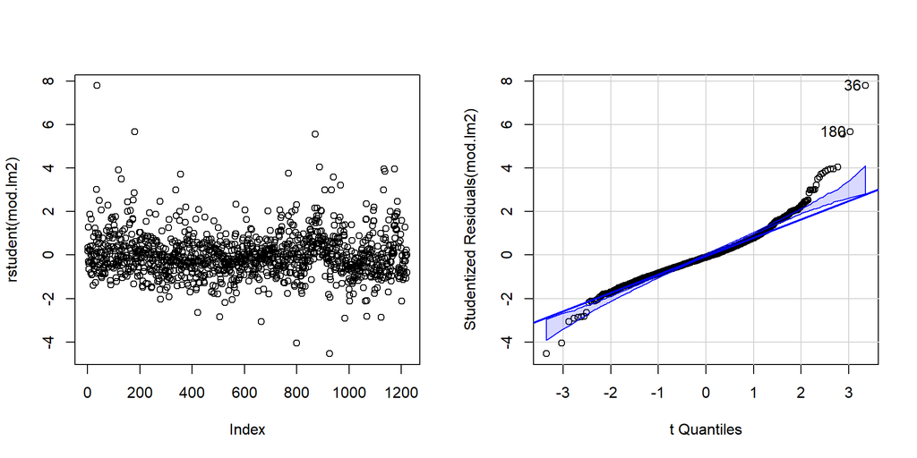

```
[1]  36 180
```

```r
par(mfrow=c(1,2))
plot(rstudent(mod.lm2))
qqPlot(mod.lm2)
```

```r
car::compareCoefs(mod.lm, mod.lm2, pvals = TRUE)
```

```
Calls:
1: lm(formula = prix_med ~ perc_log_vac + perc_maison + perc_tiny_log +
  dens_pop + med_niveau_vis + part_log_suroccup + part_agri_nb_emploi +
  part_cadre_profintellec_nbemploi, data = immo_df)
2: lm(formula = prix_med ~ perc_log_vac + perc_maison + perc_tiny_log +
  dens_pop + med_niveau_vis + part_log_suroccup + part_agri_nb_emploi +
  part_cadre_profintellec_nbemploi, data = immo_df, subset = -266)

                                 Model 1 Model 2
(Intercept)                       1592.9  1587.2
SE                                  11.2    10.5
Pr(>|z|)                         < 2e-16 < 2e-16

perc_log_vac                      -287.3  -302.2
SE                                  14.1    13.3
Pr(>|z|)                         < 2e-16 < 2e-16

perc_maison                       -128.3  -132.2
SE                                  20.0    18.8
Pr(>|z|)                         1.6e-10 2.1e-12

perc_tiny_log                     -261.6  -227.4
SE                                  27.9    26.4
Pr(>|z|)                         < 2e-16 < 2e-16

dens_pop                          173.94   -4.72
SE                                 15.27   19.98
Pr(>|z|)                         < 2e-16    0.81

med_niveau_vis                     288.0   284.9
SE                                  13.9    13.0
Pr(>|z|)                         < 2e-16 < 2e-16

part_log_suroccup                  389.0   404.2
SE                                  27.4    25.7
Pr(>|z|)                         < 2e-16 < 2e-16

part_agri_nb_emploi                -20.8   -17.5
SE                                  15.1    14.1
Pr(>|z|)                            0.17    0.21

part_cadre_profintellec_nbemploi   -7.84   23.38
SE                                 19.90   18.84
Pr(>|z|)                            0.69    0.21
```

## Introduction à la Statistique Spatiale

## Pourquoi la statistique spatiale ?

Les données spatiales ont des **propriétés particulières** :

- **Position** : les observations ont une localisation
- **Dépendance spatiale** : proximité = similitude
- **Hétérogénéité spatiale** : les processus varient dans l’espace

## Les deux problèmes fondamentaux

### 1. Autocorrélation spatiale

Les observations voisines se ressemblent

**Conséquence** : violation de l’hypothèse d’indépendance

### 2. Non-stationnarité spatiale

Les relations varient dans l’espace

**Conséquence** : coefficients non constants

## Comment la statistique spatiale répond

**Pour l’autocorrélation** :

- Mesurer et tester l’autocorrélation spatiale
- Modèles spatiaux (SAR, SEM, etc.)

**Pour la non-stationnarité** :

- Régressions géographiquement pondérées (GWR)
- Modèles locaux

## Préparation des données en vue de la stat spatiale !

## La jointure

```r
# l'option all.x = TRUE permet de garder toutes les lignes de epci_sf,
# même celles qui n'ont pas de correspondance dans immo_df
data_immo <- merge(x = epci_sf, y = immo_df, by.x = "CODE_SIREN", by.y = "SIREN", all.x = TRUE)


nrow(immo_df)
```

```
[1] 1223
```

```r
nrow(epci_sf)
```

```
[1] 1242
```

```r
nrow(data_immo)
```

```
[1] 1242
```

## Représenter

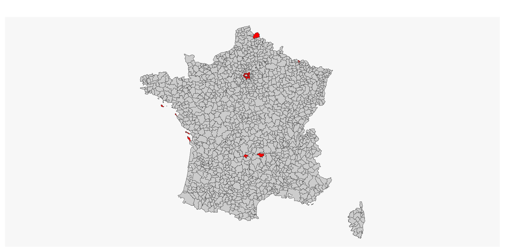

```r
mf_map(x = data_immo)
mf_map(x = data_immo[is.na(data_immo$prix_med),], col = 'red', add = TRUE)
```

## La nouvelle jointure

```r
data_immo <- merge(x = epci_sf, y = immo_df, by.x = "CODE_SIREN", by.y = "SIREN")
nrow(data_immo)
```

```
[1] 1223
```

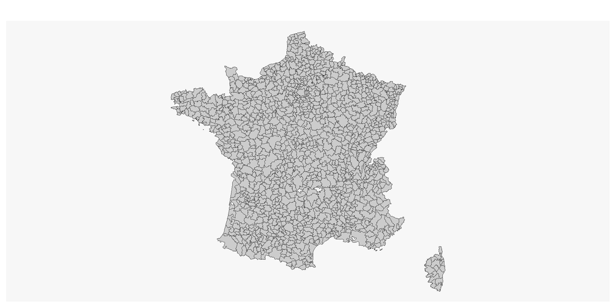

```r
mf_map(x = data_immo)
```

```r
# Pour exporter

# st_write(data_immo, "data_immo.gpkg", driver = "GPKG")
```

## La carte du prix de l’immobilier

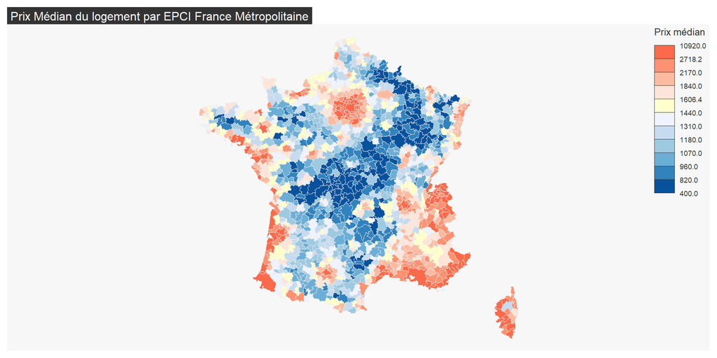

```r
# La palette de couleurs :
cols_v1 <- c("#08519c", "#3182bd", "#6baed6", "#9ecae1", "#c6dbef", "#eff3ff", "#ffffce", "#fee5d9", "#fcbba1", "#fc9272",  "#fb6a4a", "#de2d26")

# Carte du prix médian
mf_map(x = data_immo,
       var = "prix_med",
       type = "choro",
       border = "#ebebeb",
       lwd = 0.1,
       breaks=quantile(data_immo$prix_med,seq(0,1, by=1/11)),
       pal=cols_v1,
       leg_title = "Prix médian",
       leg_val_rnd = 1)
mf_title("Prix Médian du logement par EPCI France Métropolitaine") #titre
```

## La carte des résidus… ou montrer la structure spatiale

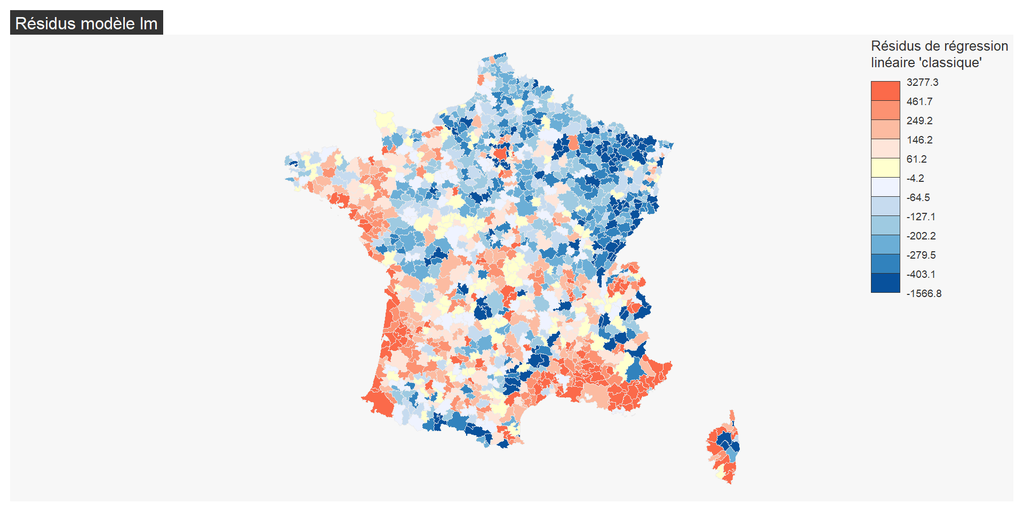

```r
data_immo$res_reg <- mod.lm$residuals

# Définition d'une palette de couleur
cols_v1 <- c("#08519c", "#3182bd", "#6baed6", "#9ecae1", "#c6dbef", "#eff3ff", "#ffffce", "#fee5d9", "#fcbba1", "#fc9272",  "#fb6a4a", "#de2d26")

# Réalisation de la carte
mf_map(x = data_immo,
       var = "res_reg",
       type = "choro",
       border = "#ebebeb",
       lwd = 0.1,
       breaks=quantile(data_immo$res_reg,seq(0,1, by=1/11)),
       pal=cols_v1,
       leg_title = "Résidus de régression\nlinéaire 'classique'",
       leg_val_rnd = 1)
mf_title("Résidus modèle lm") #titre
```

## L’Autocorrélation Spatiale

## Définition

L’autocorrélation spatiale mesure la **similitude** entre observations voisines :

- **Positive** : les valeurs similaires sont proches
- **Négative** : les valeurs dissimilaires sont proches
- **Nulle** : distribution aléatoire dans l’espace

## Représentation

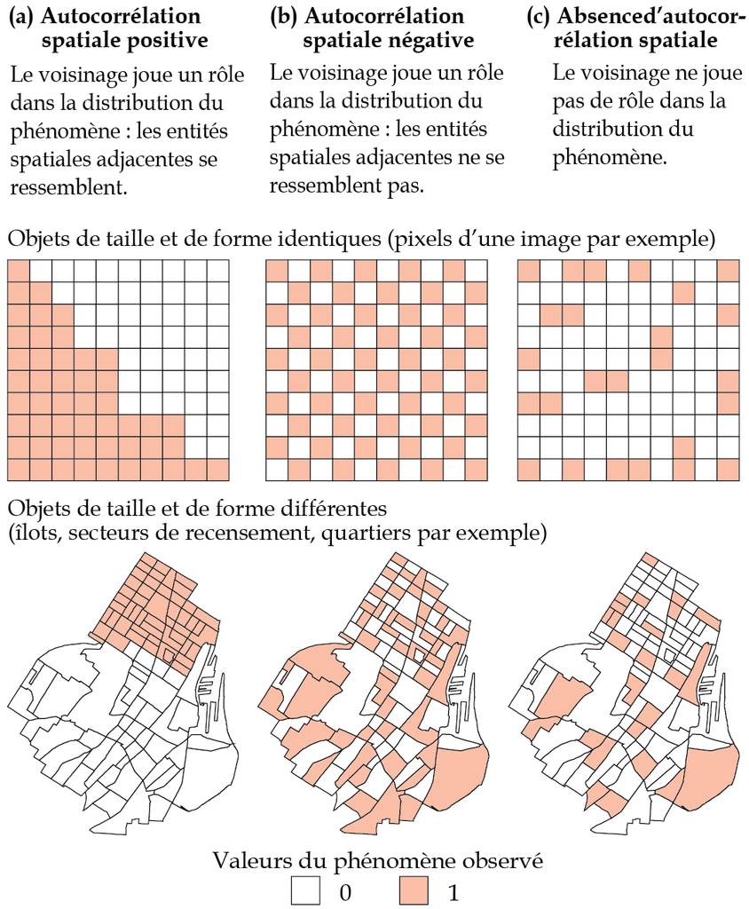

*Figure tirée de Apparicio P. et J. Gelb (2024). Méthodes d’analyse spatiales : un grand bol d’R. Université de Sherbrooke, Département de géomatique appliquée. fabriqueREL. Licence CC BY-SA*

## La matrice de poids spatiaux (1/2)

Pour mesurer l’autocorrélation, il faut définir le **voisinage** :

**Matrice W** : qui est voisin de qui ?

- $w_{ij} = 1$ si i et j sont voisins
- $w_{ij} = 0$ sinon

## La matrice de poids spatiaux (2/2)

### Différentes définitions du voisinage

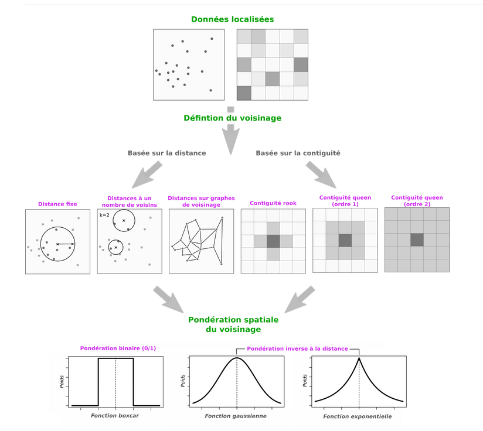

*Figure issue de Feuillet, T., Cossart, É. et Commenges, H. (2019). Manuel de géographie quantitative : Concepts, outils, méthodes. Armand Colin.*

## Voisinage avec R

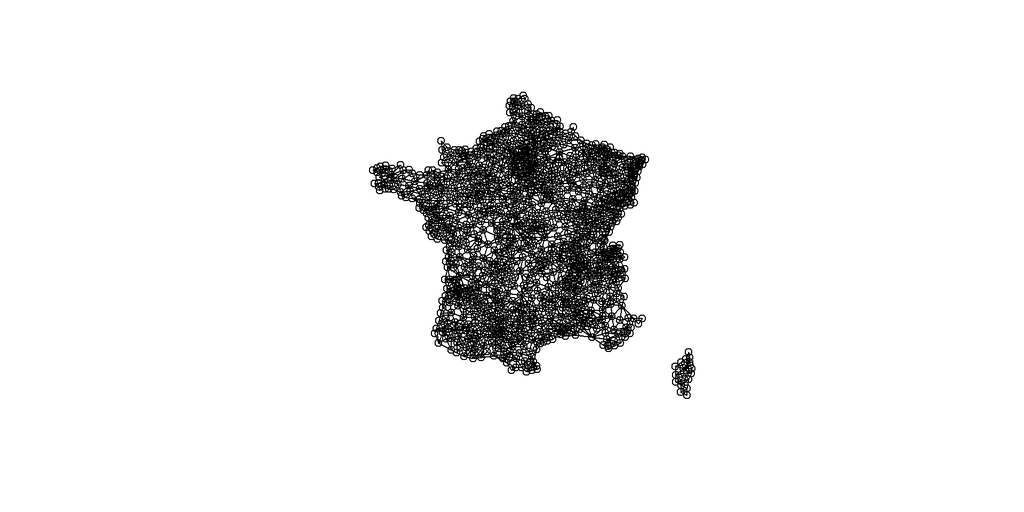

```r
library(spdep)
# Création de la liste des voisins : avec l'option queen = TRUE,
# sont considérés comme voisins 2 polygones possédant au moins 1 sommet commun
#help(poly2nb)
neighbours_epci <- poly2nb(data_immo, queen = TRUE)

# cette opération se fait aussi avec un objet sp
#shape_nbq <- poly2nb(shape, queen = TRUE)

# Obtention des coordonnées des centroïdes
#coord<-coordinates(shape)
coord <- st_coordinates(st_centroid(data_immo))

# Faire un graphe de voisinage
plot(neighbours_epci, coord)
```

```r
# si on prend le 1er élément de neighbours_epci, on voit qu'il a pour voisins les polygones 62, 74 etc.
neighbours_epci[[1]]
```

```
[1]   62   74  338 1135 1136 1137 1140
```

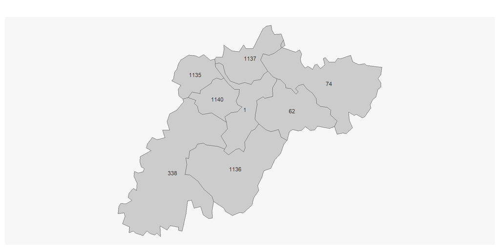

```r
# ce qu'on peut vérifier sur la carte :
neighbours1 <- data_immo[c(1,62,74,338,1135,1136,1137,1140),]
neighbours1$index <- rownames(neighbours1)
mf_map(x = neighbours1)
mf_label(x = neighbours1, var = "index")
```

## Création de la matrice de voisinage

```r
# la fonction nb2listw attribue des poids à chaque voisin
# par ex. si un polygone a 4 voisins, ils auront chacun un poids de 1/4 = 0.25
#help("nb2listw")
neighbours_epci_w <- nb2listw(neighbours_epci)
# les poids sont stockés dans le 3ème élément de neighbours_epci_w
# par ex. si on veut connaître les poids des voisins du 1er élément :
neighbours_epci_w[[3]][1]
```

```
[[1]]
[1] 0.1428571 0.1428571 0.1428571 0.1428571 0.1428571 0.1428571 0.1428571
```

**Tip**

Comment faire si l’on a un polygone sans voisins ? Sur le plan technique, la fonction nb2listw prévoit ce cas de figure. Il faut utiliser l’argument zero.policy est indiquer TRUE. Au niveau théorique, c’est moins clair. De manière générale les indices d’autocorrélation spatiale et autres régressions spatiales ont été conçus en partant du principe que les entités spatiales avaient un voisinage. Ceci dit il n’y a pas à ma connaissance de règles qui obligent à les supprimer ou intégrer, ni de consensus scientifique sur l’approche à adopter.

## L’indice de Moran (I de Moran)

$$I = \frac{n}{\sum_{i}\sum_{j}w_{ij}} \times \frac{\sum_{i}\sum_{j}w_{ij}(x_i - \bar{x})(x_j - \bar{x})}{\sum_{i}(x_i - \bar{x})^2}$$

- **I > 0** : autocorrélation positive
- **I ≈ 0** : pas d’autocorrélation
- **I < 0** : autocorrélation négative

## Interprétation de l’I de Moran

**Test d’hypothèse** :

- H₀ : distribution spatiale aléatoire (I = 0)
- H₁ : autocorrélation spatiale

**En pratique** :

- Calcul de l’indice I
- Test de significativité (permutations)
- p-value pour rejeter H₀

## Visualisation : Diagramme de Moran

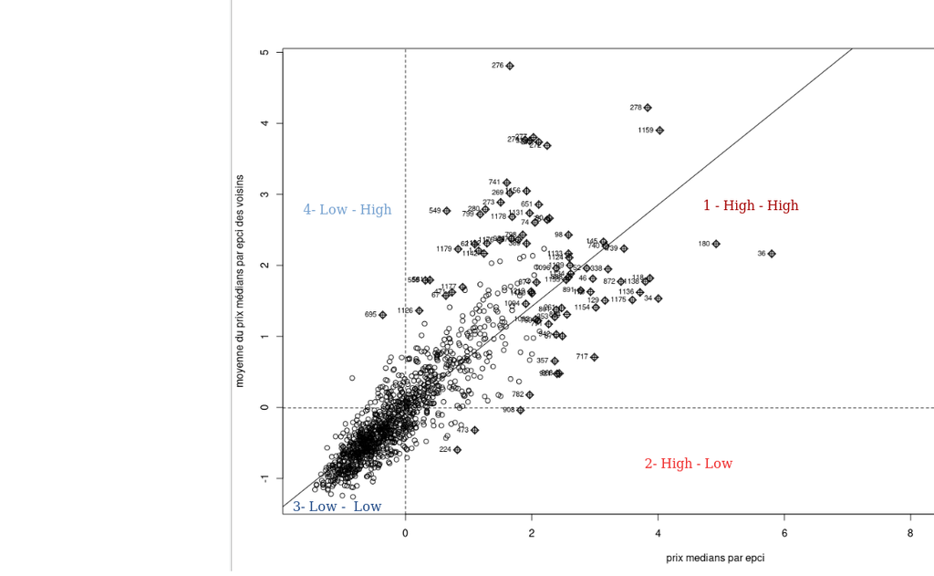

Nuage de points : valeur vs. moyenne des voisins

## Le prix de l’immobilier…

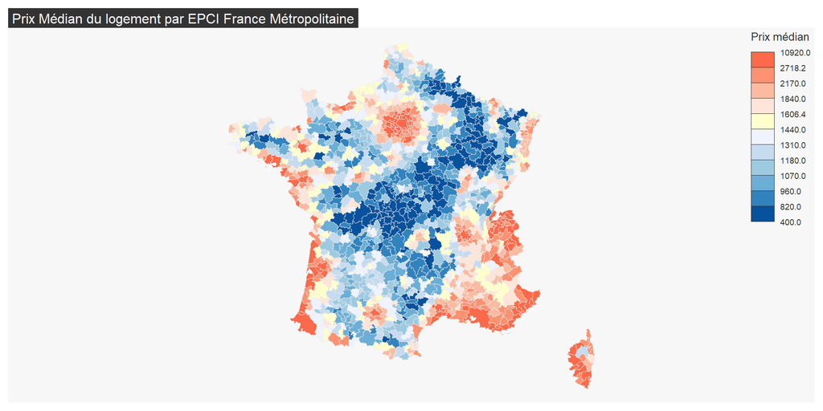

```r
# La palette de couleurs :
cols_v1 <- c("#08519c", "#3182bd", "#6baed6", "#9ecae1", "#c6dbef", "#eff3ff", "#ffffce", "#fee5d9", "#fcbba1", "#fc9272",  "#fb6a4a", "#de2d26")

# Carte du prix médian
mf_map(x = data_immo,
       var = "prix_med",
       type = "choro",
       border = "#ebebeb",
       lwd = 0.1,
       breaks=quantile(data_immo$prix_med,seq(0,1, by=1/11)),
       pal=cols_v1,
       leg_title = "Prix médian",
       leg_val_rnd = 1)
mf_title("Prix Médian du logement par EPCI France Métropolitaine") #titre
```

## Moran avec R

```r
library(spdep)

# Pour l'occasion on va standardiser notre prix médian.
# Cela permettra par la suite de le comparer à d'autres variables si d'autres analyses d'autocorrélation spatiale sont réalisées
data_immo$prix_med_z <- (data_immo$prix_med-mean(data_immo$prix_med))/sd(data_immo$prix_med)


# Test de Moran :

# On indique dans un premier temps la variable que l'on souhaite analyser
# Puis la matrice de voisinage
# L'argument zero.policy=TRUE permet de préciser que l'on souhaite intégrer à l'analyse les entités spatiales qui n'auraient pas de voisins
# L'argument randomisation=FALSE transmet à la fonction que nous supposons que la distribution est normale. Dans le cas contraire on devrait partir sur une solution de type Monte-Carlo qui repose sur la randomisation
moran.test(data_immo$prix_med_z, neighbours_epci_w, zero.policy = TRUE, randomisation = FALSE)
```

```
    Moran I test under normality

data:  data_immo$prix_med_z
weights: neighbours_epci_w

Moran I statistic standard deviate = 41.143, p-value < 2.2e-16
alternative hypothesis: greater
sample estimates:
Moran I statistic       Expectation          Variance
     0.7154340217     -0.0008183306      0.0003030652
```

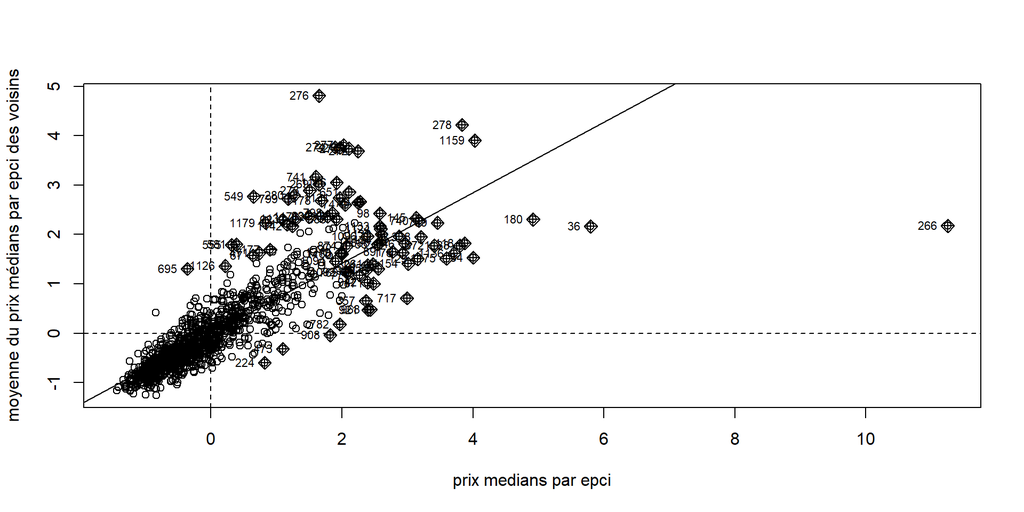

```r
moran.plot(data_immo$prix_med_z,neighbours_epci_w,
           labels = TRUE,
           xlab="prix medians par epci",
           ylab="moyenne du prix médians par epci des voisins")
```

## Les Indicateurs LISA

## Qu’est-ce que les LISA ?

**LISA** : Local Indicators of Spatial Association

- Décomposition **locale** de l’I de Moran global
- Identifie les **clusters spatiaux** locaux
- Détecte les **valeurs atypiques** spatiales

## L’indice de Moran local

Pour chaque observation i :

$$I_i = \frac{(x_i - \bar{x})}{\sigma^2} \sum_{j} w_{ij}(x_j - \bar{x})$$

Mesure la **contribution locale** à l’autocorrélation globale

## Types de clusters (1/2)

### Hot spots (HH)

Valeur élevée entourée de valeurs élevées

### Cold spots (LL)

Valeur faible entourée de valeurs faibles

### Outliers (HL)

Valeur élevée entourée de valeurs faibles

### Outliers (LH)

Valeur faible entourée de valeurs élevées

## Types de clusters (2/2)

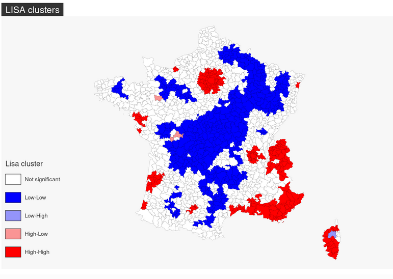

## Interprétation des LISA

**Utilité** :

- Identifier des **zones homogènes**
- Détecter des **anomalies spatiales**
- Guider les **politiques locales**
- Compléter l’analyse globale

**Attention** : tenir compte des tests de significativité !